# Классификация данных car2004

## Загрузка данных

```r
data_car <- read_excel("C:/Users/redmi/OneDrive/Документы/R analysis/car2004.xls", na = "*")
colnames(data_car) <- gsub("-", "_", colnames(data_car))

# Добавление доп.столбцов
data_car$Other <- ifelse(rowSums(data_car[c("Sport", "SportUtil", "Wagon", "Minivan", "Pickup")]) == 0, 1, 0)
data_car$Front_wheel <- ifelse(rowSums(data_car[c("All_wheel", "Rear_wheel")]) == 0, 1, 0)

# Создание категориальных переменных
data_car <- data_car %>%
mutate(
  Body_type = factor(case_when(
    Sport == 1 ~ 1,
    SportUtil == 1 ~ 2,
    Wagon == 1 ~ 3,
    Minivan == 1 ~ 4,
    Pickup == 1 ~ 5,
    Other == 1 ~ 6,
    TRUE ~ NA_integer_
  ), levels = c(1, 2, 3, 4, 5, 6), labels = c("Sport", "SportUtil", "Wagon", "Minivan", "Pickup", "Other"))
)

data_car <- data_car %>%
  mutate(
    Wheel_type = factor(case_when(
      All_wheel == 1 ~ 1,
      Rear_wheel == 1 ~ 2,
      Front_wheel == 1 ~ 3,
      TRUE ~ NA_integer_
    ), levels = c(1, 2, 3), labels = c("All_wheel", "Rear_wheel", "Front_wheel"))
  )

head(data_car, 5) |>
 print_df()
```

| Name | Sport | SportUtil | Wagon | Minivan | Pickup | All_wheel | Rear_wheel | Retail | Dealer | Engine | Cylinders | Horsepower | CityMPG | HW_MPG | Weight | WheelBase | Length | Width | Other | Front_wheel | Body_type | Wheel_type |
| --- | --- | --- | --- | --- | --- | --- | --- | --- | --- | --- | --- | --- | --- | --- | --- | --- | --- | --- | --- | --- | --- | --- |
| Chevrolet Aveo 4dr | 0 | 0 | 0 | 0 | 0 | 0 | 0 | 11690 | 10965 | 1.6 | 4 | 103 | 28 | 34 | 2370 | 98 | 167 | 66 | 1 | 1 | Other | Front_wheel |
| Chevrolet Aveo LS 4dr hatch | 0 | 0 | 0 | 0 | 0 | 0 | 0 | 12585 | 11802 | 1.6 | 4 | 103 | 28 | 34 | 2348 | 98 | 153 | 66 | 1 | 1 | Other | Front_wheel |
| Chevrolet Cavalier 2dr | 0 | 0 | 0 | 0 | 0 | 0 | 0 | 14610 | 13697 | 2.2 | 4 | 140 | 26 | 37 | 2617 | 104 | 183 | 69 | 1 | 1 | Other | Front_wheel |
| Chevrolet Cavalier 4dr | 0 | 0 | 0 | 0 | 0 | 0 | 0 | 14810 | 13884 | 2.2 | 4 | 140 | 26 | 37 | 2676 | 104 | 183 | 68 | 1 | 1 | Other | Front_wheel |
| Chevrolet Cavalier LS 2dr | 0 | 0 | 0 | 0 | 0 | 0 | 0 | 16385 | 15357 | 2.2 | 4 | 140 | 26 | 37 | 2617 | 104 | 183 | 69 | 1 | 1 | Other | Front_wheel |

1. *Name* - Название автомобиля - **качественный признак**
2. *Sport* - Спортивная машина (1=да, 0=нет) - **качественный признак** Легкие, обычно имеют мощные двигатели, способные развивать высокие скорости, чаще всего имеют задний или полный привод.
3. *SportUtil* - Внедорожник (тип кузова) (1=да, 0=нет) - **качественный признак** Характеризуется высокой посадкой, вместительным салоном, большим клиренсом и возможностью полного привода.
4. *Wagon* - Универсал (тип кузова) (1=да, 0=нет) - **качественный признак** Характеризуется увеличенным багажным отсеком, обычно имеет передний или полный привод.
5. *Minivan* - Минивэн (тип кузова) (1=да, 0=нет) - **качественный признак** Характеризуется большим количеством места для пассажиров и багажа, наиболее характерен передний привод. Некоторые модели минивэнов предлагают неплохую экономию топлива, учитывая их размер и вместительность.
6. *Pickup* - Пикап (тип кузова) (1=да, 0=нет) - **качественный признак** Характеризуется мощными двигателями и возможностью заднего или полного приводов.
7. *All-wheel* - Полный привод (1=да, 0=нет) - **качественный признак**
8. *Rear-wheel* - Задний привод (1=да, 0=нет) - **качественный признак**
9. *Retail* - Рекомендованная розничная цена в долларах (цена продажи диллером) - **количественный непрерывный**
10. *Dealer* - Закупочная цена для дилера в долларах - **количественный непрерывный**
11. *Engine* - Объем двигателя в литрах - **количественный дискретный**
12. *Cylinders* - Число цилиндров (=-1 для роторного двигателя) - **количественный дискретный**
13. *Horsepower* - Лошадиные силы - **количественный дискретный**
14. *CityMPG* - Ожидаемый пробег в милях на галлон топлива для автомобиля в условиях городского движения. - **количественный дискретный**
15. *HW_MPG* - Ожидаемый пробег в милях на галлон топлива для автомобиля в условиях движения по шоссе или трассе при постоянной скорости - **количественный дискретный**

В городском цикле обычно встречаются частые остановки, старты и пробки, что приводит к более частому использованию тормозов и ускорителей. Это может уменьшить экономию топлива.

В условиях шоссейного движения меньше остановок и меньше стартов, что может способствовать более высокой экономии топлива.

То есть ожидается, что HW_MPG > CityMPG.

16. *Weight* - Вес автомобиля в фунтах - **количественный непрерывный**
17. *WheelBase* - Расстояние между передними и задними колесами в дюймах - **количественный дискретный**
18. *Length* - Длина автомобиля в дюймах - **количественный дискретный**
19. *Width* - Ширина автомобиля в дюймах - **количественный дискретный**

Были добавлены еще два столбца, которые соответствуют другому (то есть ни одному из представленных) типу кузова (*Other*) и переднему приводу (*Front_wheel*).

Также были добавлены две категориальные переменные, отвечающие типу кузова (*Body_type*) и типу привода (*Wheel_type*).

Так как пропусков не так много, то заполним их медианным значением по каждому признаку.

```r
cols_to_fill <- c("CityMPG", "HW_MPG", "Weight", "WheelBase", "Length", "Width")
filled_cols <- na.aggregate(data_car[, cols_to_fill], FUN = median, na.rm = TRUE)
data_car[, cols_to_fill] <- filled_cols
```

Наблюдения Retail, Dealer, Engine, Horsepower, CityMPG, HW_MPG, Weight, WheelBase имеют хвост вправо, прологарифмируем их и построим графики зависимостей признаков.

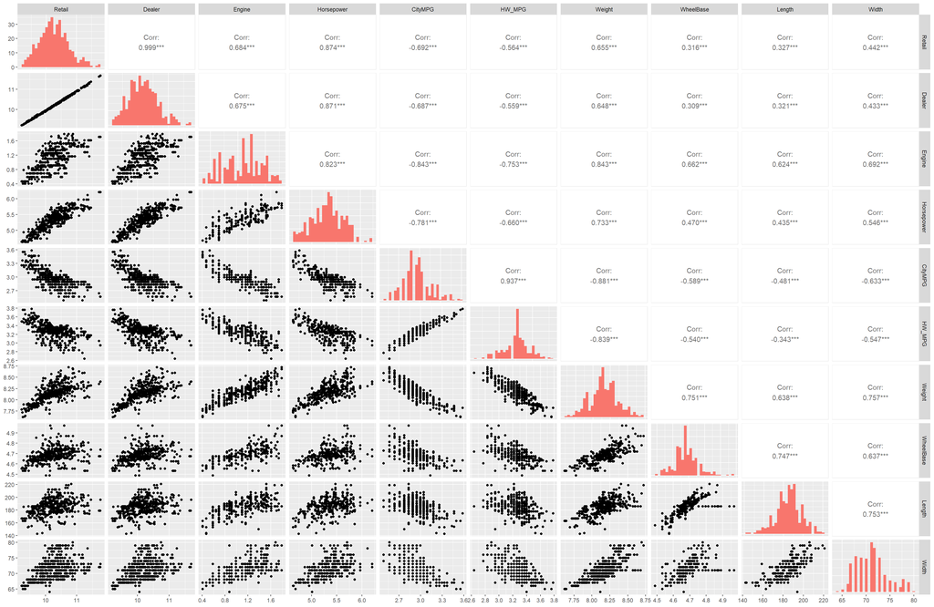

```r
data_log <- data_car %>%
  mutate_at(vars(Retail, Dealer, Engine, Horsepower, CityMPG, HW_MPG, Weight, WheelBase), ~log(.))

#Убираем сильно выделяющиеся наблюдения
data_log <- data_log[-c(69, 94, 70, 300, 97, 273, 272, 259, 305, 288, 241, 242, 419), ]

data_select <- data_log %>% dplyr::select(-Name, -Sport, -SportUtil,-Wagon, -Minivan, -Pickup, -All_wheel, -Rear_wheel, -Cylinders, -Other, -Front_wheel, -Body_type, -Wheel_type)

create_ggpairs(data_select, density_diag = FALSE)
```

**Расстояние Махаланобиса между группами по типу кузова**

```r
predictors <- c("Retail", "Engine", "Horsepower", "CityMPG", "HW_MPG", "Weight", "WheelBase", "Length", "Width")
data_predictors <- data_log[,predictors]
```

```r
mahalanobis_distances <- function(data, group){
  groups <- split(data, group)

  covariances <- lapply(groups, cov)
  centers <- lapply(groups, colMeans)

  mahalanobis_distance <- function(group1, group2, cov1, cov2, center1, center2){
    common_covariance <- (cov1 + cov2)/2
    mahalanobis(center1, center2, common_covariance)
  }

  distances <- matrix(NA, length(groups), length(groups))
  colnames(distances) <- names(groups)
  rownames(distances) <- names(groups)

  for (i in seq_along(groups)){
    for (j in seq_along(groups)){
      if (i < j){
        distances[i, j] <- mahalanobis_distance(groups[[i]], groups[[j]], covariances[[i]], covariances[[j]], centers[[i]], centers[[j]])
      }
      else if (i == j){
        distances[i, i] <- 0
      }
      else {
        distances[i, j] <- distances[j, i]
      }
    }
  }

  distances
}


distances_body <- mahalanobis_distances(data_predictors, data_log$Body_type)
print(distances_body)
```

```
##               Sport SportUtil     Wagon   Minivan    Pickup     Other
## Sport      0.000000 19.760065 10.394422 35.986278 32.207447  9.718183
## SportUtil 19.760065  0.000000  7.430774  7.014397  8.728836 17.324626
## Wagon     10.394422  7.430774  0.000000 17.141369 11.418367  1.530535
## Minivan   35.986278  7.014397 17.141369  0.000000 17.814746 23.726975
## Pickup    32.207447  8.728836 11.418367 17.814746  0.000000 14.689633
## Other      9.718183 17.324626  1.530535 23.726975 14.689633  0.000000
```

Расстояние Махаланобиса показывает, что машины типа Wagon близки к типу Other. Это действительно так, потому что машины типа Other – это седаны, хэтчбэки и купе, а эти машины, как и универсалы, это обычные машины для ежедневного использования для проезда по городу, не специализированные машины. Объединим эти группы:

```r
data_log <- data_log %>%
  mutate(Body_type_combined = factor(case_when(
    Body_type %in% c("Wagon", "Other") ~ "Ordinary",
    TRUE ~ as.character(Body_type)
  )))

distances_new_body <- mahalanobis_distances(data_predictors, data_log$Body_type_combined)
print(distances_new_body)
```

```
##             Minivan  Ordinary    Pickup     Sport SportUtil
## Minivan    0.000000 21.459652 17.814746 35.986278  7.014397
## Ordinary  21.459652  0.000000 13.399688  9.546812 14.914791
## Pickup    17.814746 13.399688  0.000000 32.207447  8.728836
## Sport     35.986278  9.546812 32.207447  0.000000 19.760065
## SportUtil  7.014397 14.914791  8.728836 19.760065  0.000000
```

**Расстояние Махаланобиса между группами по типу привода**

```r
distances_wheel <- mahalanobis_distances(data_predictors, data_log$Wheel_type)
print(distances_wheel)
```

```
##             All_wheel Rear_wheel Front_wheel
## All_wheel    0.000000   3.189907    3.639892
## Rear_wheel   3.189907   0.000000    3.139294
## Front_wheel  3.639892   3.139294    0.000000
```

По типу привода все группы достаточно близки, поэтому ожидается, что классификация будет не очень точной.

### Классификация по типу привода

**Manova**

```r
manova_wheel_type <- manova(cbind(Weight, Width, Engine, CityMPG, HW_MPG, Retail, Horsepower) ~ Wheel_type, data = data_log)

summary(manova_wheel_type, 'Wilks')
```

```
##             Df   Wilks approx F num Df den Df    Pr(>F)
## Wheel_type   2 0.47494    26.16     14    812 < 2.2e-16 ***
## Residuals  412
## ---
## Signif. codes:  0 '***' 0.001 '**' 0.01 '*' 0.05 '.' 0.1 ' ' 1
```

```r
summary(manova_wheel_type, 'Roy')
```

```
##             Df     Roy approx F num Df den Df    Pr(>F)
## Wheel_type   2 0.56231   32.694      7    407 < 2.2e-16 ***
## Residuals  412
## ---
## Signif. codes:  0 '***' 0.001 '**' 0.01 '*' 0.05 '.' 0.1 ' ' 1
```

Таким образом, различия между группами значимы.

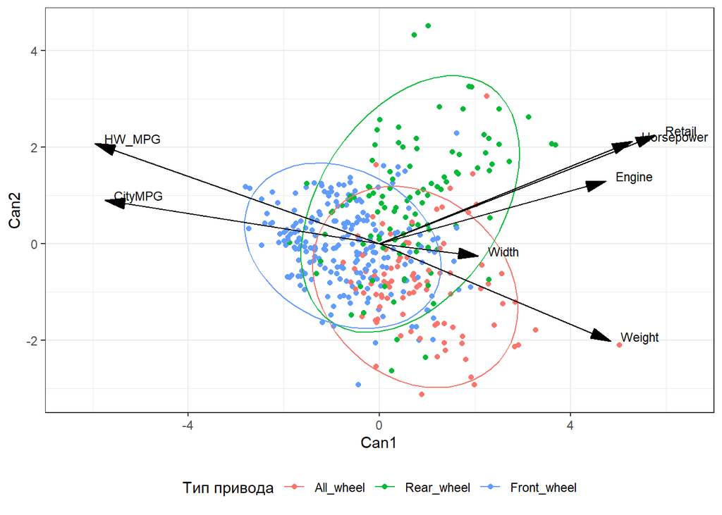

```r
res_candisc <- candisc(manova_wheel_type)

structure_df <- as.data.frame(res_candisc$structure)
structure_df$label <- rownames(structure_df)
structure_df$Can1 <- structure_df$Can1 * 7
structure_df$Can2 <- structure_df$Can2 * 7


ggplot(res_candisc$scores) +
  geom_point(aes(x = Can1, y = Can2, color = Wheel_type), size = 1.5) +
  stat_ellipse(aes(x = Can1, y = Can2, color = Wheel_type), type = "t") +
  geom_segment(data = structure_df, mapping = aes(x = 0, y = 0, xend = Can1, yend = Can2),
               arrow = arrow(angle = 15, type = "closed", length = unit(0.2, "inches")), size = 0.5) +
  geom_text(data = structure_df, mapping = aes(x = Can1, y = Can2, label = label),
            hjust = 0, nudge_x = 0.2, nudge_y = 0.1, size = 3) +
  labs(x = "Can1", y = "Can2", color = "Тип привода") +
  theme_bw() + theme(legend.position="bottom") +
  scale_x_continuous(limits = c(-7, 7), expand = c(0, 0))
```

```r
summary(res_candisc)
```

```
##
## Canonical Discriminant Analysis for Wheel_type:
##
##    CanRsq Eigenvalue Difference Percent Cumulative
## 1 0.35992    0.56231    0.21461  61.792     61.792
## 2 0.25799    0.34770    0.21461  38.208    100.000
##
## Class means:
##
##                 Can1      Can2
## All_wheel    0.90794 -0.868708
## Rear_wheel   0.69038  0.843525
## Front_wheel -0.69994 -0.054994
##
##  std coefficients:
##                Can1      Can2
## Weight     -0.15554 -1.731970
## Width      -0.32737  0.332504
## Engine      0.11460  1.135587
## CityMPG     0.38378 -0.029114
## HW_MPG     -1.10492  0.334847
## Retail      0.80933  0.515498
## Horsepower -0.17220  0.228240
```

#### LDA

```r
lda_model_cv <- lda(Wheel_type ~  Weight  + Engine + CityMPG + HW_MPG + Retail + Horsepower, data = data_log, CV = T)

lda_model <- lda(Wheel_type ~  Weight  + Engine + CityMPG + HW_MPG + Retail + Horsepower, data = data_log)
lda_model
```

```
## Call:
## lda(Wheel_type ~ Weight + Engine + CityMPG + HW_MPG + Retail +
##     Horsepower, data = data_log)
##
## Prior probabilities of groups:
##   All_wheel  Rear_wheel Front_wheel
##   0.2144578   0.2554217   0.5301205
##
## Group means:
##               Weight    Engine  CityMPG   HW_MPG   Retail Horsepower
## All_wheel   8.300655 1.2194489 2.830398 3.108663 10.43159   5.419888
## Rear_wheel  8.192573 1.2708300 2.895526 3.218851 10.58880   5.518930
## Front_wheel 8.084640 0.9725404 3.055805 3.353842 10.03187   5.181102
##
## Coefficients of linear discriminants:
##                   LD1        LD2
## Weight      2.9511606  8.1480838
## Engine     -0.4360744 -4.0384213
## CityMPG    -2.7256853  0.9724223
## HW_MPG      7.6548105 -3.8280479
## Retail     -2.2201264 -0.9302326
## Horsepower  0.5613381 -0.8930284
##
## Proportion of trace:
##  LD1  LD2
## 0.62 0.38
```

**Матрица ошибок**

*С кросс-валидацией*

```r
confusion_matrix <- table(Predicted = lda_model_cv$class, Actual = data_log$Wheel_type)
print(confusion_matrix)
```

```
##              Actual
## Predicted     All_wheel Rear_wheel Front_wheel
##   All_wheel          45         10          20
##   Rear_wheel         11         57          13
##   Front_wheel        33         39         187
```

*По всем данным*

```r
confusion_matrix <- table(Predicted = predict(lda_model)$class, Actual = data_log$Wheel_type)
print(confusion_matrix)
```

```
##              Actual
## Predicted     All_wheel Rear_wheel Front_wheel
##   All_wheel          47         10          19
##   Rear_wheel          9         60          12
##   Front_wheel        33         36         189
```

**Accuracy**

```r
accuracy <- sum(diag(confusion_matrix)) / sum(confusion_matrix)
print(paste("Accuracy:", round(accuracy, 2)))
```

```
## [1] "Accuracy: 0.71"
```

**Precision, Recall и F1-score для каждого класса**

```r
metrics <- calculate_metrics(confusion_matrix, data_log$Wheel_type)
datatable(metrics)
```

|  | Class | Precision | Recall | F1_score |
| --- | --- | --- | --- | --- |
| 1 | All_wheel | 0.62 | 0.53 | 0.57 |
| 2 | Rear_wheel | 0.74 | 0.57 | 0.64 |
| 3 | Front_wheel | 0.73 | 0.86 | 0.79 |

На основе $F_1$-score можно сказать, что классификация действительно в данном случае является не очень хорошей. Наиболее точно классифицируется группа Front_wheel (что ожидаемо, так как она самая большая и у нее самый большой вес).

#### QDA

```r
qda_model <- qda(Wheel_type ~  Weight  + Engine + CityMPG + HW_MPG + Retail + Horsepower, data = data_log)

qda_model_cv <- qda(Wheel_type ~  Weight  + Engine + CityMPG + HW_MPG + Retail + Horsepower, data = data_log, CV = T)

qda_model
```

```
## Call:
## qda(Wheel_type ~ Weight + Engine + CityMPG + HW_MPG + Retail +
##     Horsepower, data = data_log)
##
## Prior probabilities of groups:
##   All_wheel  Rear_wheel Front_wheel
##   0.2144578   0.2554217   0.5301205
##
## Group means:
##               Weight    Engine  CityMPG   HW_MPG   Retail Horsepower
## All_wheel   8.300655 1.2194489 2.830398 3.108663 10.43159   5.419888
## Rear_wheel  8.192573 1.2708300 2.895526 3.218851 10.58880   5.518930
## Front_wheel 8.084640 0.9725404 3.055805 3.353842 10.03187   5.181102
```

**Матрица ошибок**

*С кросс-валидацией*

```r
confusion_matrix <- table(Predicted = qda_model_cv$class, Actual = data_log$Wheel_type)
print(confusion_matrix)
```

```
##              Actual
## Predicted     All_wheel Rear_wheel Front_wheel
##   All_wheel          41         13          29
##   Rear_wheel         11         65          11
##   Front_wheel        37         28         180
```

*По всем данным*

```r
confusion_matrix <- table(Predicted = predict(qda_model)$class, Actual = data_log$Wheel_type)
print(confusion_matrix)
```

```
##              Actual
## Predicted     All_wheel Rear_wheel Front_wheel
##   All_wheel          50         12          26
##   Rear_wheel          9         68          11
##   Front_wheel        30         26         183
```

**Accuracy**

```r
accuracy <- sum(diag(confusion_matrix)) / sum(confusion_matrix)
print(paste("Accuracy:", round(accuracy, 2)))
```

```
## [1] "Accuracy: 0.73"
```

**Precision, Recall и F1-score для каждого класса**

```r
metrics <- calculate_metrics(confusion_matrix, data_log$Wheel_type)
datatable(metrics)
```

|  | Class | Precision | Recall | F1_score |
| --- | --- | --- | --- | --- |
| 1 | All_wheel | 0.57 | 0.56 | 0.56 |
| 2 | Rear_wheel | 0.77 | 0.64 | 0.7 |
| 3 | Front_wheel | 0.77 | 0.83 | 0.8 |

### Классификация по типу кузова

**Manova**

```r
manova_body_type <- manova(cbind(Length, WheelBase, Width, Weight, Engine, CityMPG, HW_MPG, Retail, Horsepower) ~ Body_type_combined, data = data_log)

summary(manova_body_type, 'Wilks')
```

```
##                     Df    Wilks approx F num Df den Df    Pr(>F)
## Body_type_combined   4 0.068566   43.758     36 1508.2 < 2.2e-16 ***
## Residuals          410
## ---
## Signif. codes:  0 '***' 0.001 '**' 0.01 '*' 0.05 '.' 0.1 ' ' 1
```

```r
summary(manova_body_type, 'Roy')
```

```
##                     Df    Roy approx F num Df den Df    Pr(>F)
## Body_type_combined   4 2.9098   130.94      9    405 < 2.2e-16 ***
## Residuals          410
## ---
## Signif. codes:  0 '***' 0.001 '**' 0.01 '*' 0.05 '.' 0.1 ' ' 1
```

Таким образом, различия между группами значимы.

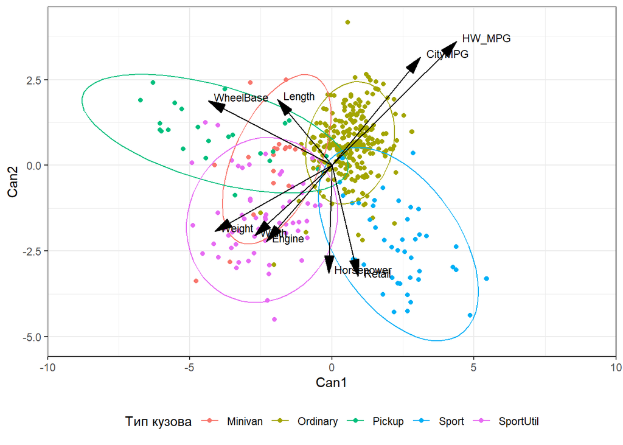

```r
res_candisc <- candisc(manova_body_type)

structure_df <- as.data.frame(res_candisc$structure)
structure_df$label <- rownames(structure_df)
structure_df$Can1 <- structure_df$Can1 * 7
structure_df$Can2 <- structure_df$Can2 * 7


ggplot(res_candisc$scores) +
  geom_point(aes(x = Can1, y = Can2, color = Body_type_combined), size = 1.5) +
  stat_ellipse(aes(x = Can1, y = Can2, color = Body_type_combined), type = "t") +
  geom_segment(data = structure_df, mapping = aes(x = 0, y = 0, xend = Can1, yend = Can2),
               arrow = arrow(angle = 15, type = "closed", length = unit(0.2, "inches")), size = 0.5) +
  geom_text(data = structure_df, mapping = aes(x = Can1, y = Can2, label = label),
            hjust = 0, nudge_x = 0.2, nudge_y = 0.1, size = 3) +
  labs(x = "Can1", y = "Can2", color = "Тип кузова") +
  theme_bw() + theme(legend.position="bottom") +
  scale_x_continuous(limits = c(-10, 10), expand = c(0, 0))
```

```r
summary(res_candisc)
```

```
##
## Canonical Discriminant Analysis for Body_type_combined:
##
##    CanRsq Eigenvalue Difference Percent Cumulative
## 1 0.74423    2.90981     1.7056 61.4817     61.482
## 2 0.54633    1.20423     1.7056 25.4444     86.926
## 3 0.31427    0.45831     1.7056  9.6837     96.610
## 4 0.13827    0.16045     1.7056  3.3902    100.000
##
## Class means:
##
##               Can1      Can2     Can3
## Minivan   -2.20503  0.050444  0.92154
## Ordinary   0.64584  0.627115  0.11741
## Pickup    -3.96645  0.922138 -2.21593
## Sport      2.38412 -2.279154 -0.81481
## SportUtil -2.51184 -1.523277  0.64862
##
##  std coefficients:
##                 Can1     Can2      Can3
## Length      0.424888  0.88238  0.974113
## WheelBase  -0.601620  0.77689 -1.142879
## Width      -0.051764 -1.07970  0.395650
## Weight     -1.318763  0.23990  1.316635
## Engine      0.057202 -0.22370 -0.544050
## CityMPG    -1.090131 -0.41249  0.646764
## HW_MPG      1.362897  0.82500 -0.070277
## Retail      0.907454 -0.14870  0.224751
## Horsepower  0.585688 -0.34892 -0.612069
```

#### LDA

```r
lda_model <- lda(Body_type_combined ~  Length + WheelBase + Width + Weight  + Engine + CityMPG + HW_MPG + Retail + Horsepower, data = data_log)

lda_model_cv <- lda(Body_type_combined ~  Length + WheelBase + Width + Weight  + Engine + CityMPG + HW_MPG + Retail + Horsepower, data = data_log, CV = T)

lda_model
```

```
## Call:
## lda(Body_type_combined ~ Length + WheelBase + Width + Weight +
##     Engine + CityMPG + HW_MPG + Retail + Horsepower, data = data_log)
##
## Prior probabilities of groups:
##    Minivan   Ordinary     Pickup      Sport  SportUtil
## 0.04819277 0.64819277 0.05542169 0.10843373 0.13975904
##
## Group means:
##             Length WheelBase    Width   Weight   Engine  CityMPG   HW_MPG
## Minivan   197.1500  4.764965 76.15000 8.339140 1.254903 2.881472 3.191127
## Ordinary  185.8216  4.673282 70.41636 8.097657 1.013615 3.035726 3.347969
## Pickup    186.0000  4.804239 71.00000 8.321956 1.339547 2.798877 3.038392
## Sport     173.1556  4.611764 70.75556 8.092909 1.172492 2.917587 3.245622
## SportUtil 187.4310  4.703839 73.81034 8.364717 1.308028 2.779360 3.023313
##             Retail Horsepower
## Minivan   10.22130   5.312818
## Ordinary  10.18125   5.248529
## Pickup    10.04870   5.365393
## Sport     10.70509   5.581560
## SportUtil 10.37593   5.423004
##
## Coefficients of linear discriminants:
##                     LD1          LD2         LD3         LD4
## Length       0.03600947  -0.07478199 -0.08255652 -0.09954722
## WheelBase  -10.37321710 -13.39523236 19.70568558 16.25510277
## Width       -0.01832064   0.38213284 -0.14002978  0.47489193
## Weight      -7.97721635  -1.45116827 -7.96434279 -4.21757383
## Engine       0.18547233   0.72531232  1.76402551  0.10426884
## CityMPG     -6.44986549   2.44054808 -3.82664229 -5.85560946
## HW_MPG       9.72533524  -5.88702139  0.50148131  8.13332189
## Retail       2.03619226   0.33366919 -0.50430728  0.73142160
## Horsepower   1.98737372   1.18396339  2.07689077 -1.10827286
##
## Proportion of trace:
##    LD1    LD2    LD3    LD4
## 0.6148 0.2544 0.0968 0.0339
```

**Матрица ошибок**

*С кросс-валидацией*

```r
confusion_matrix <- table(Predicted = lda_model_cv$class, Actual = data_log$Body_type_combined)
print(confusion_matrix)
```

```
##            Actual
## Predicted   Minivan Ordinary Pickup Sport SportUtil
##   Minivan        12        1      0     0         4
##   Ordinary        5      259      5    10         6
##   Pickup          0        0     15     0         2
##   Sport           0        6      0    35         0
##   SportUtil       3        3      3     0        46
```

*По всем данным*

```r
confusion_matrix <- table(Predicted = predict(lda_model)$class, Actual = data_log$Body_type_combined)
print(confusion_matrix)
```

```
##            Actual
## Predicted   Minivan Ordinary Pickup Sport SportUtil
##   Minivan        13        1      0     0         2
##   Ordinary        4      261      5    10         6
##   Pickup          0        0     16     0         2
##   Sport           0        4      0    35         0
##   SportUtil       3        3      2     0        48
```

**Accuracy**

```r
accuracy <- sum(diag(confusion_matrix)) / sum(confusion_matrix)
print(paste("Accuracy:", round(accuracy, 2)))
```

```
## [1] "Accuracy: 0.9"
```

**Precision, Recall и F1-score для каждого класса**

```r
metrics <- calculate_metrics(confusion_matrix, data_log$Body_type_combined)
datatable(metrics)
```

|  | Class | Precision | Recall | F1_score |
| --- | --- | --- | --- | --- |
| 1 | Minivan | 0.81 | 0.65 | 0.72 |
| 2 | Ordinary | 0.91 | 0.97 | 0.94 |
| 3 | Pickup | 0.89 | 0.7 | 0.78 |
| 4 | Sport | 0.9 | 0.78 | 0.83 |
| 5 | SportUtil | 0.86 | 0.83 | 0.84 |

Классификация LDA по типу кузова, основываясь на $F_1$-score, является достаточно хорошей. Наиболее точно, как и ожидается, классифицируется группа Ordinary наибольшего размера (с большим весом).

Классификацию QDA в данном случае не удается построить, так как из-за заполнения медианным знаяением признака WheelBase у Pickup ковариационная матрица становится вырожденной.

### Классификация по типу кузова (Спортивные машины и внедорожники)

```r
data_log_ss <- data_log %>%
  filter(Sport == 1 | SportUtil == 1)%>%
  mutate(
  Body_type = factor(case_when(
    Sport == 1 ~ 1,
    SportUtil == 1 ~ 2,
    TRUE ~ NA_integer_
  ), levels = c(1, 2), labels = c("Sport", "SportUtil"))
)
```

#### Проверка данных на нормальность

```r
library(MVN)

data_da <- data_log_ss %>%
  dplyr::select(HW_MPG, CityMPG, Retail, WheelBase,  Width, Length, Horsepower, Body_type)

result <- mvn(data = data_da, subset = "Body_type", mvnTest = "mardia")
result$multivariateNormality
```

```
## $Sport
##              Test         Statistic            p value Result
## 1 Mardia Skewness  99.1680050983964  0.123609391541086    YES
## 2 Mardia Kurtosis -1.86957649324236 0.0615426521045015    YES
## 3             MVN              <NA>               <NA>    YES
##
## $SportUtil
##              Test        Statistic              p value Result
## 1 Mardia Skewness 134.656955776261 0.000378118511473265     NO
## 2 Mardia Kurtosis 1.85851387918643    0.063096074289384    YES
## 3             MVN             <NA>                 <NA>     NO
```

#### Проверка гипотезы о равенстве ковариационных матриц (Box’s M Test)

```r
library(biotools)

res <- boxM(data_da[, 1:7], data_da$Body_type)
res
```

```
##
##  Box's M-test for Homogeneity of Covariance Matrices
##
## data:  data_da[, 1:7]
## Chi-Sq (approx.) = 78.494, df = 28, p-value = 1.116e-06
```

Гипотеза о равенстве ковариационных матриц отвергается.

#### Проверка гипотезы о равенстве мат.ожиданий в классах

**Manova**

```r
manova_body_type_ss <- manova(cbind(HW_MPG, CityMPG, Retail, WheelBase,  Width, Length, Horsepower) ~ Body_type, data = data_da)

summary(manova_body_type_ss, 'Wilks')
```

```
##            Df   Wilks approx F num Df den Df    Pr(>F)
## Body_type   1 0.20015   54.234      7     95 < 2.2e-16 ***
## Residuals 101
## ---
## Signif. codes:  0 '***' 0.001 '**' 0.01 '*' 0.05 '.' 0.1 ' ' 1
```

```r
summary(manova_body_type_ss, 'Roy')
```

```
##            Df    Roy approx F num Df den Df    Pr(>F)
## Body_type   1 3.9962   54.234      7     95 < 2.2e-16 ***
## Residuals 101
## ---
## Signif. codes:  0 '***' 0.001 '**' 0.01 '*' 0.05 '.' 0.1 ' ' 1
```

```r
res_candisc <- candisc(manova_body_type_ss)
summary(res_candisc)
```

```
##
## Canonical Discriminant Analysis for Body_type:
##
##    CanRsq Eigenvalue Difference Percent Cumulative
## 1 0.79985     3.9962                100        100
##
## Class means:
##
## [1] -2.2474  1.7436
##
##  std coefficients:
##     HW_MPG    CityMPG     Retail  WheelBase      Width     Length Horsepower
##   -1.47586    0.47130   -0.38603    0.22802    0.33738    0.29848   -1.04185
```

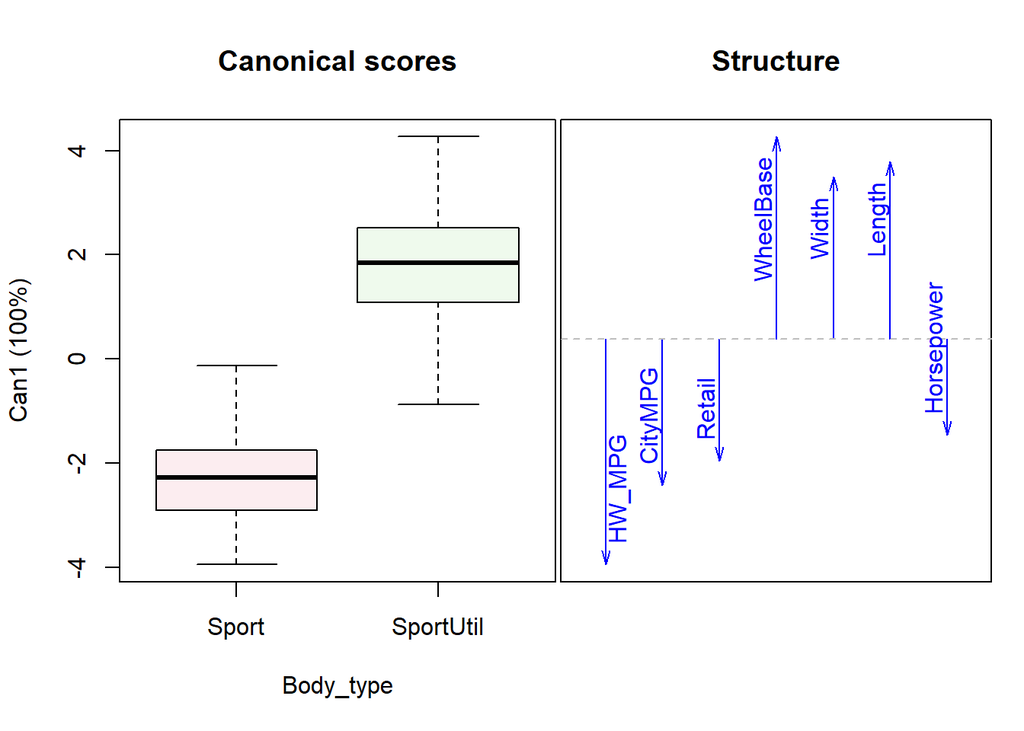

```r
plot(res_candisc)
```

И тесты, и визуальное представление указывают на то, что мат.ожидания в классах не равны.

**Hotelling**

```r
library(Hotelling)

sport <- data_da %>%
  filter(Body_type == "Sport")  %>%
  select_if(is.numeric)

sportutil <- data_da %>%
  filter(Body_type == "SportUtil")  %>%
  select_if(is.numeric)

hotelling_result <- hotelling.test(sport, sportutil)
hotelling_result
```

```
## Test stat:  403.62
## Numerator df:  7
## Denominator df:  95
## P-value:  0
```

Гипотеза о равенстве мат.ожиданий отвергается.

#### LDA

```r
lda_model <- lda(Body_type ~  HW_MPG + CityMPG + Retail + WheelBase + Width + Length + Horsepower,
                 data = data_da)

lda_model_cv <- lda(Body_type ~  HW_MPG + CityMPG + Retail + WheelBase + Width + Length + Horsepower,
                 data = data_da, CV = T)
lda_model
```

```
## Call:
## lda(Body_type ~ HW_MPG + CityMPG + Retail + WheelBase + Width +
##     Length + Horsepower, data = data_da)
##
## Prior probabilities of groups:
##     Sport SportUtil
## 0.4368932 0.5631068
##
## Group means:
##             HW_MPG  CityMPG   Retail WheelBase    Width   Length Horsepower
## Sport     3.245622 2.917587 10.70509  4.611764 70.75556 173.1556   5.581560
## SportUtil 3.023313 2.779360 10.37593  4.703839 73.81034 187.4310   5.423004
##
## Coefficients of linear discriminants:
##                     LD1
## HW_MPG     -11.27903068
## CityMPG      3.15402978
## Retail      -0.87681292
## WheelBase    3.52092033
## Width        0.11594235
## Length       0.02473404
## Horsepower  -3.78093363
```

**Матрица ошибок**

*С кросс-валидацией*

```r
confusion_matrix <- table(Predicted = lda_model_cv$class, Actual = data_da$Body_type)
print(confusion_matrix)
```

```
##            Actual
## Predicted   Sport SportUtil
##   Sport        44         2
##   SportUtil     1        56
```

*По всем данным*

```r
confusion_matrix <- table(Predicted = predict(lda_model)$class, Actual = data_da$Body_type)
print(confusion_matrix)
```

```
##            Actual
## Predicted   Sport SportUtil
##   Sport        44         1
##   SportUtil     1        57
```

**Accuracy**

```r
accuracy <- sum(diag(confusion_matrix)) / sum(confusion_matrix)
print(paste("Accuracy:", round(accuracy, 2)))
```

```
## [1] "Accuracy: 0.98"
```

**Precision, Recall и F1-score для каждого класса**

```r
metrics <- calculate_metrics(confusion_matrix, data_da$Body_type)
datatable(metrics)
```

|  | Class | Precision | Recall | F1_score |
| --- | --- | --- | --- | --- |
| 1 | Sport | 0.98 | 0.98 | 0.98 |
| 2 | SportUtil | 0.98 | 0.98 | 0.98 |

По всем метрикам получается, что качества классификации очень хорошее.

#### Визуализация

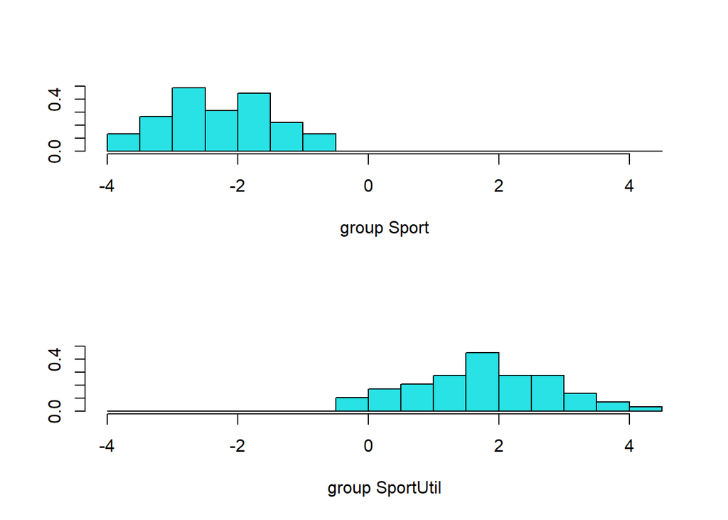

```r
full_predict <- predict(lda_model, data_da[,1:7])
ldahist(full_predict$x[,1], g = full_predict$class)
```

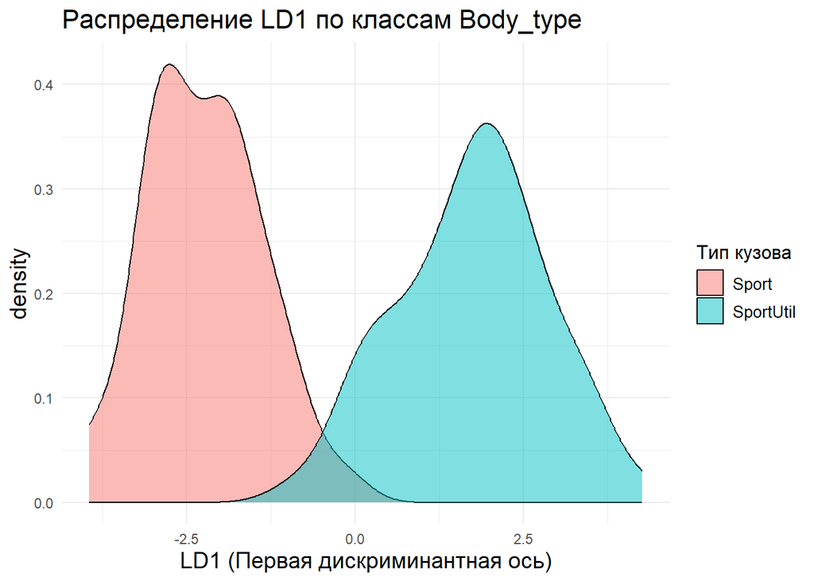

```r
lda_plot_df <- data.frame(LD1 = full_predict$x[, 1],
                          Body_type = data_da$Body_type)

ggplot(lda_plot_df, aes(x = LD1, fill = Body_type)) +
  geom_density(alpha = 0.5) +
  labs(title = "Распределение LD1 по классам Body_type",
       x = "LD1 (Первая дискриминантная ось)",
       fill = "Тип кузова") +
  theme_minimal() +
  theme(
    plot.title = element_text(size = 16),
    axis.title = element_text(size = 14),
    legend.title = element_text(size = 12),
    legend.text = element_text(size = 10)
  )
```

**ROC-кривая**

*По всем данным*

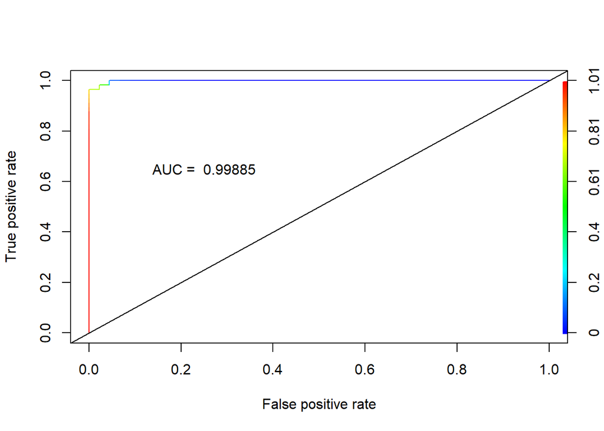

```r
ldap <- predict(lda_model, data_da[, 1:7])
pred <- prediction(ldap$posterior[,2], data_da$Body_type)
perf <- performance(pred, "tpr", "fpr")
plot(perf, colorize = TRUE)
AUC.ROCR <- performance(pred, "auc")
abline(a = 0, b = 1)
text(x = .25, y = .65, paste("AUC = ", round(AUC.ROCR@y.values[[1]],5)))
```

*С кросс-валидацией*

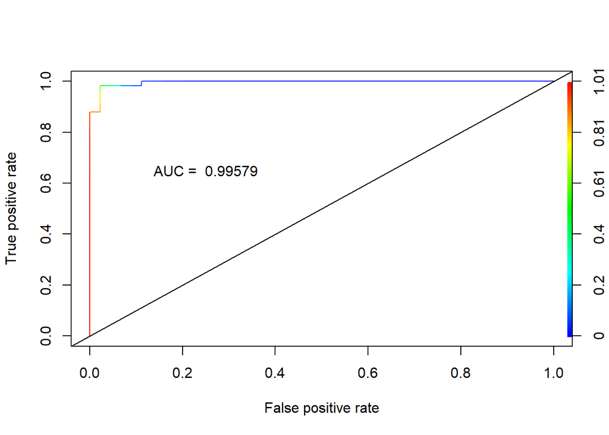

```r
predcv <- prediction(lda_model_cv$posterior[,2], data_da$Body_type)
perfcv <- performance(predcv, "tpr", "fpr")
plot(perfcv, colorize = TRUE)
AUCcv <- performance(predcv, "auc")
abline(a = 0, b = 1)
text(x = .25, y = .65, paste("AUC = ", round(AUCcv@y.values[[1]],5)))
```

Рисуем ROC-кривые на одной картинке. Сверху находится ROC-кривая классификации на полных данных, что проверяется по AUC

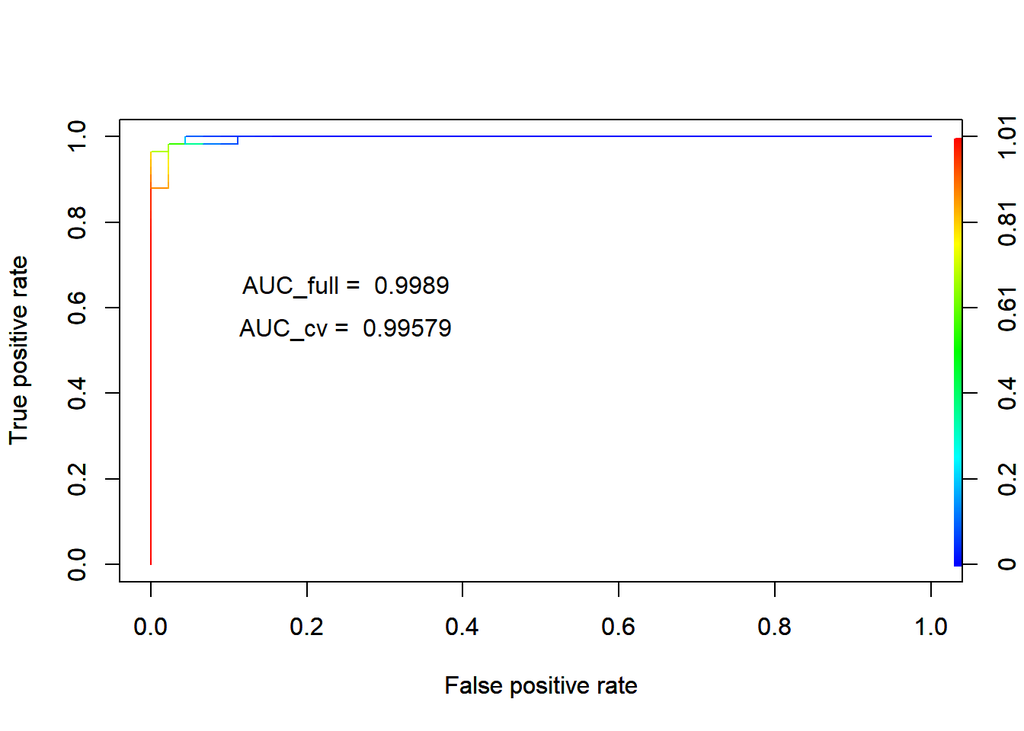

```r
plot(perfcv, colorize = TRUE)
par(new = T)
plot(perf, colorize = TRUE)
text(x = .25, y = .55, paste("AUC_cv = ", round(AUCcv@y.values[[1]],5)))
text(x = .25, y = .65, paste("AUC_full = ", round(AUC.ROCR@y.values[[1]],4)))
```

#### QDA

```r
qda_model <- qda(Body_type ~  HW_MPG + CityMPG + Retail + WheelBase + Width + Length + Horsepower,
                 data = data_da)

qda_model_cv <- qda(Body_type ~  HW_MPG + CityMPG + Retail + WheelBase + Width + Length + Horsepower,
                 data = data_da, CV = T)
qda_model
```

```
## Call:
## qda(Body_type ~ HW_MPG + CityMPG + Retail + WheelBase + Width +
##     Length + Horsepower, data = data_da)
##
## Prior probabilities of groups:
##     Sport SportUtil
## 0.4368932 0.5631068
##
## Group means:
##             HW_MPG  CityMPG   Retail WheelBase    Width   Length Horsepower
## Sport     3.245622 2.917587 10.70509  4.611764 70.75556 173.1556   5.581560
## SportUtil 3.023313 2.779360 10.37593  4.703839 73.81034 187.4310   5.423004
```

**Матрица ошибок**

*С кросс-валидацией*

```r
confusion_matrix <- table(Predicted = qda_model_cv$class, Actual = data_da$Body_type)
print(confusion_matrix)
```

```
##            Actual
## Predicted   Sport SportUtil
##   Sport        43         1
##   SportUtil     2        57
```

*По всем данным*

```r
confusion_matrix <- table(Predicted = predict(qda_model)$class, Actual = data_da$Body_type)
print(confusion_matrix)
```

```
##            Actual
## Predicted   Sport SportUtil
##   Sport        43         1
##   SportUtil     2        57
```

**Accuracy**

```r
accuracy <- sum(diag(confusion_matrix)) / sum(confusion_matrix)
print(paste("Accuracy:", round(accuracy, 2)))
```

```
## [1] "Accuracy: 0.97"
```

**Precision, Recall и F1-score для каждого класса**

```r
metrics <- calculate_metrics(confusion_matrix, data_da$Body_type)
datatable(metrics)
```

|  | Class | Precision | Recall | F1_score |
| --- | --- | --- | --- | --- |
| 1 | Sport | 0.98 | 0.96 | 0.97 |
| 2 | SportUtil | 0.97 | 0.98 | 0.97 |

QDA немного уступает LDA по качеству классификации.

**ROC-кривая**

*По всем данным*

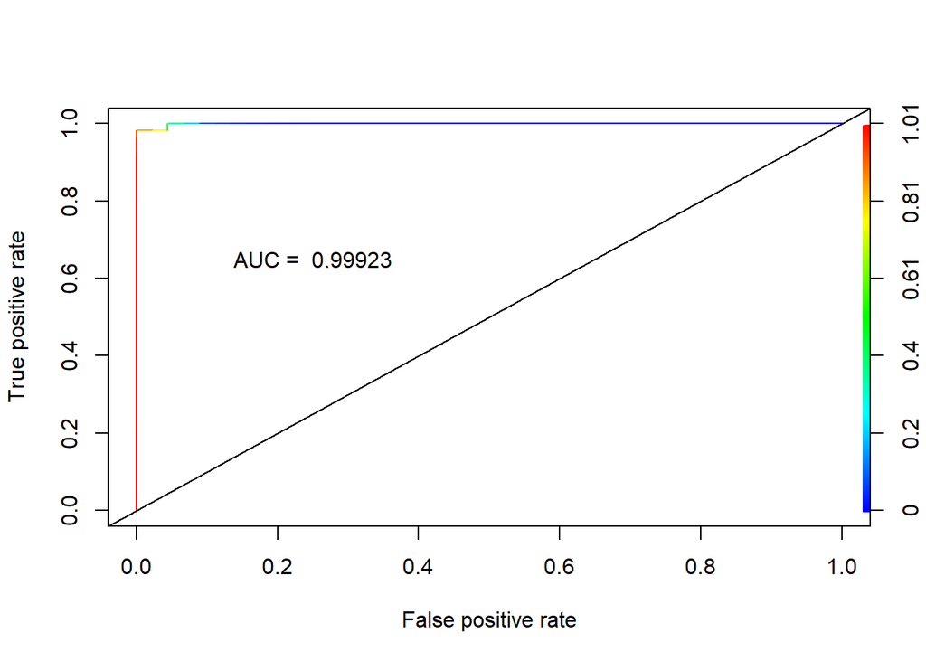

```r
qdap <- predict(qda_model, data_da[, 1:7])
pred <- prediction(qdap$posterior[,2], data_da$Body_type)
perf <- performance(pred, "tpr", "fpr")
plot(perf, colorize = TRUE)
AUC.ROCR <- performance(pred, "auc")
abline(a = 0, b = 1)
text(x = .25, y = .65, paste("AUC = ", round(AUC.ROCR@y.values[[1]],5)))
```

*С кросс-валидацией*

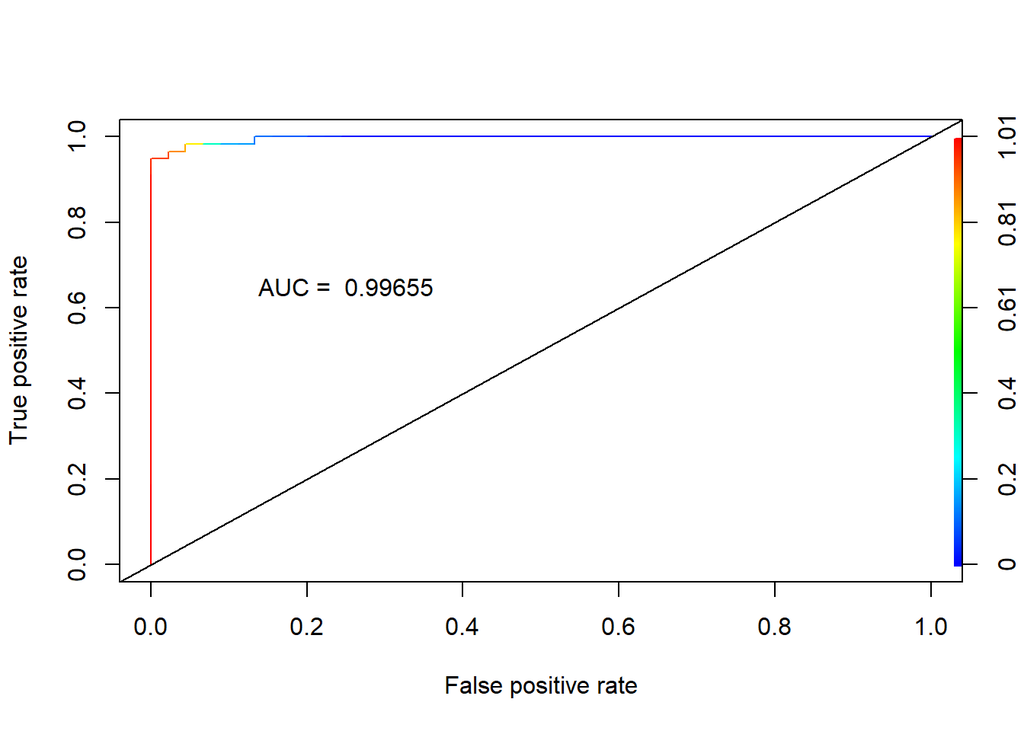

```r
predcv <- prediction(qda_model_cv$posterior[,2], data_da$Body_type)
perfcv <- performance(predcv, "tpr", "fpr")
plot(perfcv, colorize = TRUE)
AUCcv <- performance(predcv, "auc")
abline(a = 0, b = 1)
text(x = .25, y = .65, paste("AUC = ", round(AUCcv@y.values[[1]],5)))
```

Рисуем ROC-кривые на одной картинке. Сверху находится ROC-кривая классификации на полных данных, что проверяется по AUC

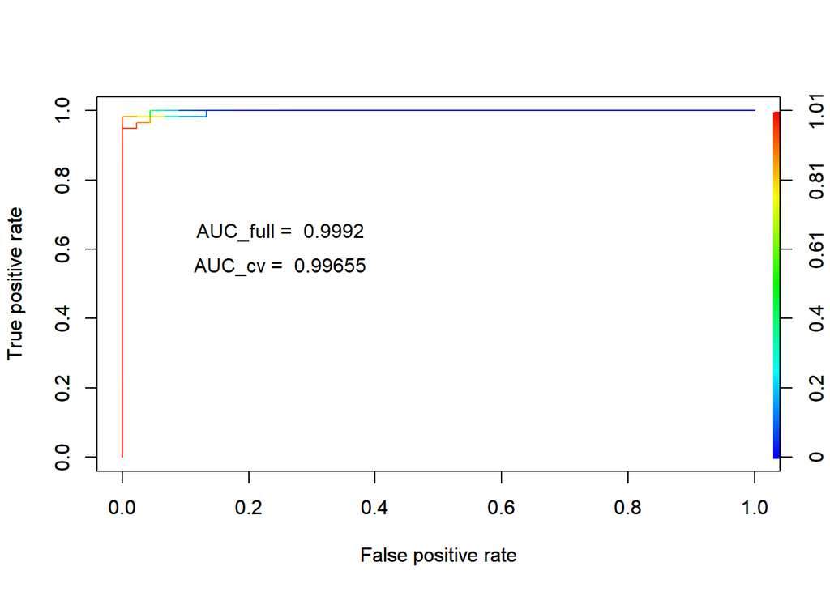

```r
plot(perfcv, colorize = TRUE)
par(new = T)
plot(perf, colorize = TRUE)
text(x = .25, y = .55, paste("AUC_cv = ", round(AUCcv@y.values[[1]],5)))
text(x = .25, y = .65, paste("AUC_full = ", round(AUC.ROCR@y.values[[1]],4)))
```